# Project: Investigate a Soccer Dataset

- Introduction
- Data Wrangling
- Exploratory Data Analysis
- Conclusions

## Introduction

This soccer database comes from Kaggle. It records information on leagues, matches, players and teams from 11 European countries between 2008 and 2016. This report will focus on soccer players's attibutes, and try to answer the following questions:

- Who are the top 5 rated soccer players?
- Which attributies are highly correlated to players's overall rating?
- Which players had the most penalties?

```python
# Import libraries
import sqlite3
import pandas as pd
import numpy as np
import matplotlib.pyplot as plt
import seaborn as sns
%matplotlib inline
```

## Data Wrangling

In this section, we will load in the data, check for cleanliness, and then trim and clean the selected tables for analysis.

##### Selected tables:

- Player
- Player_Attributes

### Access the datasets

```python
# Creating the connection to dataset
con = sqlite3.connect('database.sqlite')
cur = con.cursor()

cur.execute("SELECT name FROM sqlite_master WHERE type='table';")
cur.fetchall()
```

```
[('sqlite_sequence',),
 ('Player_Attributes',),
 ('Player',),
 ('Match',),
 ('League',),
 ('Country',),
 ('Team',),
 ('Team_Attributes',)]
```

```python
con.close
```

```
<function Connection.close>
```

```python
# Loading Player table with Pandas
player = pd.read_sql('SELECT * FROM Player', con)
player.head(1)
```

|  | id | player_api_id | player_name | player_fifa_api_id | birthday | height | weight |
| --- | --- | --- | --- | --- | --- | --- | --- |
| 0 | 1 | 505942 | Aaron Appindangoye | 218353 | 1992-02-29 00:00:00 | 182.88 | 187 |

```python
# Loading Player_Attributes table
player_attributes = pd.read_sql('SELECT * FROM Player_Attributes', con)
player_attributes.head(1)
```

|  | id | player_fifa_api_id | player_api_id | date | overall_rating | potential | preferred_foot | attacking_work_rate | defensive_work_rate | crossing | ... | vision | penalties | marking | standing_tackle | sliding_tackle | gk_diving | gk_handling | gk_kicking | gk_positioning | gk_reflexes |
| --- | --- | --- | --- | --- | --- | --- | --- | --- | --- | --- | --- | --- | --- | --- | --- | --- | --- | --- | --- | --- | --- |
| 0 | 1 | 218353 | 505942 | 2016-02-18 00:00:00 | 67.0 | 71.0 | right | medium | medium | 49.0 | ... | 54.0 | 48.0 | 65.0 | 69.0 | 69.0 | 6.0 | 11.0 | 10.0 | 8.0 | 8.0 |

1 rows × 42 columns

### Assessing Data

In this part, I will try to get the following information:

- Number of samples in selected tables
- Number of columns in selected tables
- Datatypes of columns
- Duplicate rows in each tables
- Any missing values

#### *Basic information*

```python
player.shape
```

```
(11060, 7)
```

```python
# Get to know the basic information of player
player.info()
```

```
<class 'pandas.core.frame.DataFrame'>
RangeIndex: 11060 entries, 0 to 11059
Data columns (total 7 columns):
id                    11060 non-null int64
player_api_id         11060 non-null int64
player_name           11060 non-null object
player_fifa_api_id    11060 non-null int64
birthday              11060 non-null object
height                11060 non-null float64
weight                11060 non-null int64
dtypes: float64(1), int64(4), object(2)
memory usage: 604.9+ KB
```

```python
# Get to know the basic information of player_attributes
player_attributes.info()
```

```
<class 'pandas.core.frame.DataFrame'>
RangeIndex: 183978 entries, 0 to 183977
Data columns (total 42 columns):
id                     183978 non-null int64
player_fifa_api_id     183978 non-null int64
player_api_id          183978 non-null int64
date                   183978 non-null object
overall_rating         183142 non-null float64
potential              183142 non-null float64
preferred_foot         183142 non-null object
attacking_work_rate    180748 non-null object
defensive_work_rate    183142 non-null object
crossing               183142 non-null float64
finishing              183142 non-null float64
heading_accuracy       183142 non-null float64
short_passing          183142 non-null float64
volleys                181265 non-null float64
dribbling              183142 non-null float64
curve                  181265 non-null float64
free_kick_accuracy     183142 non-null float64
long_passing           183142 non-null float64
ball_control           183142 non-null float64
acceleration           183142 non-null float64
sprint_speed           183142 non-null float64
agility                181265 non-null float64
reactions              183142 non-null float64
balance                181265 non-null float64
shot_power             183142 non-null float64
jumping                181265 non-null float64
stamina                183142 non-null float64
strength               183142 non-null float64
long_shots             183142 non-null float64
aggression             183142 non-null float64
interceptions          183142 non-null float64
positioning            183142 non-null float64
vision                 181265 non-null float64
penalties              183142 non-null float64
marking                183142 non-null float64
standing_tackle        183142 non-null float64
sliding_tackle         181265 non-null float64
gk_diving              183142 non-null float64
gk_handling            183142 non-null float64
gk_kicking             183142 non-null float64
gk_positioning         183142 non-null float64
gk_reflexes            183142 non-null float64
dtypes: float64(35), int64(3), object(4)
memory usage: 59.0+ MB
```

```python
# Inspect date's type
type(player_attributes.date[0])
```

```
str
```

**Note:**

- The type of date is string.
- The data types of preferred_foot, attacking_work_rate, and defensive_work_rate are object.

#### *Duplication*

```python
# check any duplicated rows for player
sum(player.duplicated())
```

```
0
```

```python
# Check if any name duplicated
player.player_name.duplicated().sum()
```

```
212
```

```python
# Check if player_api_id is unique
player.duplicated(["player_api_id"]).sum()
```

```
0
```

```python
# check any duplicated rows for player_att
sum(player_attributes.duplicated())
```

```
0
```

**Note:**

- There are 212 repeated player's names.

#### *Missing data*

```python
# check if player contains any missing values, and look at the type of each cloumn
player[player.isnull().any(axis=1)].info()
```

```
<class 'pandas.core.frame.DataFrame'>
Int64Index: 0 entries
Data columns (total 7 columns):
id                    0 non-null int64
player_api_id         0 non-null int64
player_name           0 non-null object
player_fifa_api_id    0 non-null int64
birthday              0 non-null object
height                0 non-null float64
weight                0 non-null int64
dtypes: float64(1), int64(4), object(2)
memory usage: 0.0+ bytes
```

```python
# check if player_attributes contains any missing values, and get t the type of each cloumn
player_attributes[player_attributes.isnull().any(axis=1)].info()
```

```
<class 'pandas.core.frame.DataFrame'>
Int64Index: 3624 entries, 373 to 183967
Data columns (total 42 columns):
id                     3624 non-null int64
player_fifa_api_id     3624 non-null int64
player_api_id          3624 non-null int64
date                   3624 non-null object
overall_rating         2788 non-null float64
potential              2788 non-null float64
preferred_foot         2788 non-null object
attacking_work_rate    394 non-null object
defensive_work_rate    2788 non-null object
crossing               2788 non-null float64
finishing              2788 non-null float64
heading_accuracy       2788 non-null float64
short_passing          2788 non-null float64
volleys                911 non-null float64
dribbling              2788 non-null float64
curve                  911 non-null float64
free_kick_accuracy     2788 non-null float64
long_passing           2788 non-null float64
ball_control           2788 non-null float64
acceleration           2788 non-null float64
sprint_speed           2788 non-null float64
agility                911 non-null float64
reactions              2788 non-null float64
balance                911 non-null float64
shot_power             2788 non-null float64
jumping                911 non-null float64
stamina                2788 non-null float64
strength               2788 non-null float64
long_shots             2788 non-null float64
aggression             2788 non-null float64
interceptions          2788 non-null float64
positioning            2788 non-null float64
vision                 911 non-null float64
penalties              2788 non-null float64
marking                2788 non-null float64
standing_tackle        2788 non-null float64
sliding_tackle         911 non-null float64
gk_diving              2788 non-null float64
gk_handling            2788 non-null float64
gk_kicking             2788 non-null float64
gk_positioning         2788 non-null float64
gk_reflexes            2788 non-null float64
dtypes: float64(35), int64(3), object(4)
memory usage: 1.2+ MB
```

**Summary**:

- No. of samples in each dataset: 11060 (player), 183978 (player_attributes)
- No. of columns in each dataset: 7 (player), 42 (player_attributes)
- No duplicated rows found in all datasets. However, there are many players having same name.
- No missing data found in player dataset, but a lot of missing values in player_attributes dataset.

### Data Cleaning:

In this part, I will perform the following actions:

- Drop any rows with missing values
- Fix data type
- Merge datasets
- Select interested columns

#### *Covert string to datetime*

```python
# Change date from str type to datetime
player_attributes["date"] = pd.to_datetime(player_attributes["date"])
player_attributes.date.head(1)
```

```
0   2016-02-18
Name: date, dtype: datetime64[ns]
```

#### *Drop rows with missing values*

```python
# In order to keep orginal player_attibutes table, create a new one:
player_att = player_attributes.dropna()
```

```python
# Confirm the change made
player_att.isnull().sum()
```

```
id                     0
player_fifa_api_id     0
player_api_id          0
date                   0
overall_rating         0
potential              0
preferred_foot         0
attacking_work_rate    0
defensive_work_rate    0
crossing               0
finishing              0
heading_accuracy       0
short_passing          0
volleys                0
dribbling              0
curve                  0
free_kick_accuracy     0
long_passing           0
ball_control           0
acceleration           0
sprint_speed           0
agility                0
reactions              0
balance                0
shot_power             0
jumping                0
stamina                0
strength               0
long_shots             0
aggression             0
interceptions          0
positioning            0
vision                 0
penalties              0
marking                0
standing_tackle        0
sliding_tackle         0
gk_diving              0
gk_handling            0
gk_kicking             0
gk_positioning         0
gk_reflexes            0
dtype: int64
```

```python
player_att.info()
```

```
<class 'pandas.core.frame.DataFrame'>
Int64Index: 180354 entries, 0 to 183977
Data columns (total 42 columns):
id                     180354 non-null int64
player_fifa_api_id     180354 non-null int64
player_api_id          180354 non-null int64
date                   180354 non-null datetime64[ns]
overall_rating         180354 non-null float64
potential              180354 non-null float64
preferred_foot         180354 non-null object
attacking_work_rate    180354 non-null object
defensive_work_rate    180354 non-null object
crossing               180354 non-null float64
finishing              180354 non-null float64
heading_accuracy       180354 non-null float64
short_passing          180354 non-null float64
volleys                180354 non-null float64
dribbling              180354 non-null float64
curve                  180354 non-null float64
free_kick_accuracy     180354 non-null float64
long_passing           180354 non-null float64
ball_control           180354 non-null float64
acceleration           180354 non-null float64
sprint_speed           180354 non-null float64
agility                180354 non-null float64
reactions              180354 non-null float64
balance                180354 non-null float64
shot_power             180354 non-null float64
jumping                180354 non-null float64
stamina                180354 non-null float64
strength               180354 non-null float64
long_shots             180354 non-null float64
aggression             180354 non-null float64
interceptions          180354 non-null float64
positioning            180354 non-null float64
vision                 180354 non-null float64
penalties              180354 non-null float64
marking                180354 non-null float64
standing_tackle        180354 non-null float64
sliding_tackle         180354 non-null float64
gk_diving              180354 non-null float64
gk_handling            180354 non-null float64
gk_kicking             180354 non-null float64
gk_positioning         180354 non-null float64
gk_reflexes            180354 non-null float64
dtypes: datetime64[ns](1), float64(35), int64(3), object(3)
memory usage: 59.2+ MB
```

```python
# Check if each player_api_id is unique
player.player_api_id.nunique()
```

```
11060
```

```python
player_attributes.player_api_id.nunique()
```

```
11060
```

```python
player.player_name.nunique()
```

```
10848
```

```python
# Find the rows having duplicated names
rows_name_repeated = player[player.duplicated("player_name")]
rows_name_repeated.head()
```

|  | id | player_api_id | player_name | player_fifa_api_id | birthday | height | weight |
| --- | --- | --- | --- | --- | --- | --- | --- |
| 85 | 86 | 41749 | Adailton | 4769 | 1977-01-24 00:00:00 | 175.26 | 161 |
| 99 | 100 | 420209 | Adam Drury | 205162 | 1993-09-09 00:00:00 | 177.80 | 152 |
| 138 | 139 | 533212 | Adama Traore | 225151 | 1995-06-28 00:00:00 | 177.80 | 159 |
| 191 | 192 | 30690 | Adriano | 106019 | 1982-02-17 00:00:00 | 187.96 | 194 |
| 192 | 193 | 33992 | Adriano | 164082 | 1984-10-26 00:00:00 | 172.72 | 161 |

```python
# Find indexes of the rows having duplicated names
index = player[player.duplicated("player_name")].index
index
```

```
Int64Index([   85,    99,   138,   191,   192,   193,   405,   438,   439,
              515,
            ...
            10266, 10447, 10655, 10713, 10714, 10739, 10756, 11018, 11021,
            11030],
           dtype='int64', length=212)
```

```python
# Rename duplicated names as "player_name"_"player_api_id" format
rows_name_repeated.loc[:,"player_name"] = rows_name_repeated['player_name'].str.cat(rows_name_repeated['player_api_id'].astype(str), sep ="_")
rows_name_repeated.head(1)
```

|  | id | player_api_id | player_name | player_fifa_api_id | birthday | height | weight |
| --- | --- | --- | --- | --- | --- | --- | --- |
| 85 | 86 | 41749 | Adailton_41749 | 4769 | 1977-01-24 00:00:00 | 175.26 | 161 |

```python
# Drop all rows having duplicated name
player.drop(index, inplace=True)
```

```python
# Confirm the changes
player.player_name.duplicated().sum()
```

```
0
```

```python
# Add new rows having renamed players
player_updated = pd.concat([player,rows_name_repeated])
player_updated.head()
```

|  | id | player_api_id | player_name | player_fifa_api_id | birthday | height | weight |
| --- | --- | --- | --- | --- | --- | --- | --- |
| 0 | 1 | 505942 | Aaron Appindangoye | 218353 | 1992-02-29 00:00:00 | 182.88 | 187 |
| 1 | 2 | 155782 | Aaron Cresswell | 189615 | 1989-12-15 00:00:00 | 170.18 | 146 |
| 2 | 3 | 162549 | Aaron Doran | 186170 | 1991-05-13 00:00:00 | 170.18 | 163 |
| 3 | 4 | 30572 | Aaron Galindo | 140161 | 1982-05-08 00:00:00 | 182.88 | 198 |
| 4 | 5 | 23780 | Aaron Hughes | 17725 | 1979-11-08 00:00:00 | 182.88 | 154 |

```python
player_updated.tail()
```

|  | id | player_api_id | player_name | player_fifa_api_id | birthday | height | weight |
| --- | --- | --- | --- | --- | --- | --- | --- |
| 10739 | 10755 | 121957 | Wellington_121957 | 184845 | 1988-02-11 00:00:00 | 187.96 | 198 |
| 10756 | 10772 | 25617 | Wesley_25617 | 163092 | 1980-11-10 00:00:00 | 180.34 | 159 |
| 11018 | 11034 | 185867 | Ze Eduardo_185867 | 181132 | 1987-10-29 00:00:00 | 177.80 | 185 |
| 11021 | 11037 | 570159 | Ze Manuel_570159 | 223339 | 1990-10-23 00:00:00 | 177.80 | 157 |
| 11030 | 11046 | 244155 | Zezinho_244155 | 212639 | 1992-09-23 00:00:00 | 175.26 | 161 |

#### *Merge datasets*

In this part, I will combine new player table without repeated player name to player_attributes table

```python
# Merge player_updated and player_att
player_combined = pd.merge(player_updated, player_att,how="inner", on="player_api_id")
player_combined.head(1)
```

|  | id_x | player_api_id | player_name | player_fifa_api_id_x | birthday | height | weight | id_y | player_fifa_api_id_y | date | ... | vision | penalties | marking | standing_tackle | sliding_tackle | gk_diving | gk_handling | gk_kicking | gk_positioning | gk_reflexes |
| --- | --- | --- | --- | --- | --- | --- | --- | --- | --- | --- | --- | --- | --- | --- | --- | --- | --- | --- | --- | --- | --- |
| 0 | 1 | 505942 | Aaron Appindangoye | 218353 | 1992-02-29 00:00:00 | 182.88 | 187 | 1 | 218353 | 2016-02-18 | ... | 54.0 | 48.0 | 65.0 | 69.0 | 69.0 | 6.0 | 11.0 | 10.0 | 8.0 | 8.0 |

1 rows × 48 columns

#### *Select columns*

In this part, I will drop some columns not interested in this data analysis.

```python
# What columns do the new dataset have?
player_combined.columns
```

```
Index(['id_x', 'player_api_id', 'player_name', 'player_fifa_api_id_x',
       'birthday', 'height', 'weight', 'id_y', 'player_fifa_api_id_y', 'date',
       'overall_rating', 'potential', 'preferred_foot', 'attacking_work_rate',
       'defensive_work_rate', 'crossing', 'finishing', 'heading_accuracy',
       'short_passing', 'volleys', 'dribbling', 'curve', 'free_kick_accuracy',
       'long_passing', 'ball_control', 'acceleration', 'sprint_speed',
       'agility', 'reactions', 'balance', 'shot_power', 'jumping', 'stamina',
       'strength', 'long_shots', 'aggression', 'interceptions', 'positioning',
       'vision', 'penalties', 'marking', 'standing_tackle', 'sliding_tackle',
       'gk_diving', 'gk_handling', 'gk_kicking', 'gk_positioning',
       'gk_reflexes'],
      dtype='object')
```

```python
# Directly drop some uninterested columns
player_clean = player_combined.drop(['id_x', 'player_fifa_api_id_x',
       'birthday', 'weight', 'id_y', 'player_fifa_api_id_y', "preferred_foot", "attacking_work_rate", "defensive_work_rate"],axis = 1)
player_clean.head(1)
```

|  | player_api_id | player_name | height | date | overall_rating | potential | crossing | finishing | heading_accuracy | short_passing | ... | vision | penalties | marking | standing_tackle | sliding_tackle | gk_diving | gk_handling | gk_kicking | gk_positioning | gk_reflexes |
| --- | --- | --- | --- | --- | --- | --- | --- | --- | --- | --- | --- | --- | --- | --- | --- | --- | --- | --- | --- | --- | --- |
| 0 | 505942 | Aaron Appindangoye | 182.88 | 2016-02-18 | 67.0 | 71.0 | 49.0 | 44.0 | 71.0 | 61.0 | ... | 54.0 | 48.0 | 65.0 | 69.0 | 69.0 | 6.0 | 11.0 | 10.0 | 8.0 | 8.0 |

1 rows × 39 columns

```python
player_clean.info()
```

```
<class 'pandas.core.frame.DataFrame'>
Int64Index: 180354 entries, 0 to 180353
Data columns (total 39 columns):
player_api_id         180354 non-null int64
player_name           180354 non-null object
height                180354 non-null float64
date                  180354 non-null datetime64[ns]
overall_rating        180354 non-null float64
potential             180354 non-null float64
crossing              180354 non-null float64
finishing             180354 non-null float64
heading_accuracy      180354 non-null float64
short_passing         180354 non-null float64
volleys               180354 non-null float64
dribbling             180354 non-null float64
curve                 180354 non-null float64
free_kick_accuracy    180354 non-null float64
long_passing          180354 non-null float64
ball_control          180354 non-null float64
acceleration          180354 non-null float64
sprint_speed          180354 non-null float64
agility               180354 non-null float64
reactions             180354 non-null float64
balance               180354 non-null float64
shot_power            180354 non-null float64
jumping               180354 non-null float64
stamina               180354 non-null float64
strength              180354 non-null float64
long_shots            180354 non-null float64
aggression            180354 non-null float64
interceptions         180354 non-null float64
positioning           180354 non-null float64
vision                180354 non-null float64
penalties             180354 non-null float64
marking               180354 non-null float64
standing_tackle       180354 non-null float64
sliding_tackle        180354 non-null float64
gk_diving             180354 non-null float64
gk_handling           180354 non-null float64
gk_kicking            180354 non-null float64
gk_positioning        180354 non-null float64
gk_reflexes           180354 non-null float64
dtypes: datetime64[ns](1), float64(36), int64(1), object(1)
memory usage: 55.0+ MB
```

**Summary**:

- No. of samples in the cleaned table: 180354
- No. of columns in the cleaned table: 39

## Exploratory Data Analysis

In this section, we will compute statistics and create visualizations to better address our research questions described in the Introduction section. We will use systematic approach - look at one variable at a time, and then follow it up by looking at relationships between variables.

### Research Question 1: Who are the top 5 rated scoccer players?

```python
# Find top 5 players based on their mean value of overall_rating
rating = player_clean.groupby("player_name").overall_rating.mean().sort_values(ascending=False)
rating.head()
```

```
player_name
Lionel Messi          92.192308
Cristiano Ronaldo     91.280000
Franck Ribery         88.458333
Andres Iniesta        88.320000
Zlatan Ibrahimovic    88.285714
Name: overall_rating, dtype: float64
```

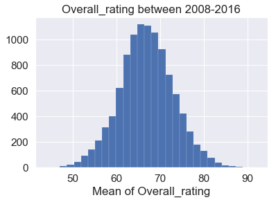

```python
# Look at distribution of player's rating
rating.hist(bins= 30, edgecolor="white", linewidth =0.15)
plt.title("Overall_rating between 2008-2016")
plt.xlabel("Mean of Overall_rating");
```

```python
# Get information
rating.describe()
```

```
count    10226.000000
mean        66.894994
std          6.148358
min         43.750000
25%         62.935294
50%         66.800000
75%         70.948611
max         92.192308
Name: overall_rating, dtype: float64
```

```python
# How good is the most top player ?
rating.max() - rating.mean()
```

```
25.297313494986867
```

### Research Question 2: Which attributies are highly correlated to players' overall rating?

#### *Feature selection*

In this part, I will filter and take only the subset of the relevant features by processing the following steps:

```python
# Calculate the mean values of each player's attributes
player_clean_mean = player_clean.groupby("player_api_id").mean()
player_clean_mean.head(1)
```

| player_api_id | height | overall_rating | potential | crossing | finishing | heading_accuracy | short_passing | volleys | dribbling | curve | ... | vision | penalties | marking | standing_tackle | sliding_tackle | gk_diving | gk_handling | gk_kicking | gk_positioning | gk_reflexes |
| --- | --- | --- | --- | --- | --- | --- | --- | --- | --- | --- | --- | --- | --- | --- | --- | --- | --- | --- | --- | --- | --- |
| 2625 | 175.26 | 60.142857 | 61.142857 | 50.142857 | 47.285714 | 46.285714 | 56.5 | 38.0 | 54.142857 | 50.0 | ... | 55.285714 | 61.928571 | 62.928571 | 63.857143 | 56.571429 | 12.428571 | 12.857143 | 19.071429 | 10.357143 | 10.428571 |

1 rows × 36 columns

```python
# Generate the correlation matrix
cor = player_clean_mean.corr()
cor.head(1)
```

|  | height | overall_rating | potential | crossing | finishing | heading_accuracy | short_passing | volleys | dribbling | curve | ... | vision | penalties | marking | standing_tackle | sliding_tackle | gk_diving | gk_handling | gk_kicking | gk_positioning | gk_reflexes |
| --- | --- | --- | --- | --- | --- | --- | --- | --- | --- | --- | --- | --- | --- | --- | --- | --- | --- | --- | --- | --- | --- |
| height | 1.0 | 0.0063 | -0.036203 | -0.496311 | -0.323137 | 0.091814 | -0.382368 | -0.33791 | -0.508739 | -0.459153 | ... | -0.398128 | -0.294581 | 0.025756 | 0.009952 | -0.008486 | 0.322712 | 0.320543 | 0.24429 | 0.322308 | 0.323359 |

1 rows × 36 columns

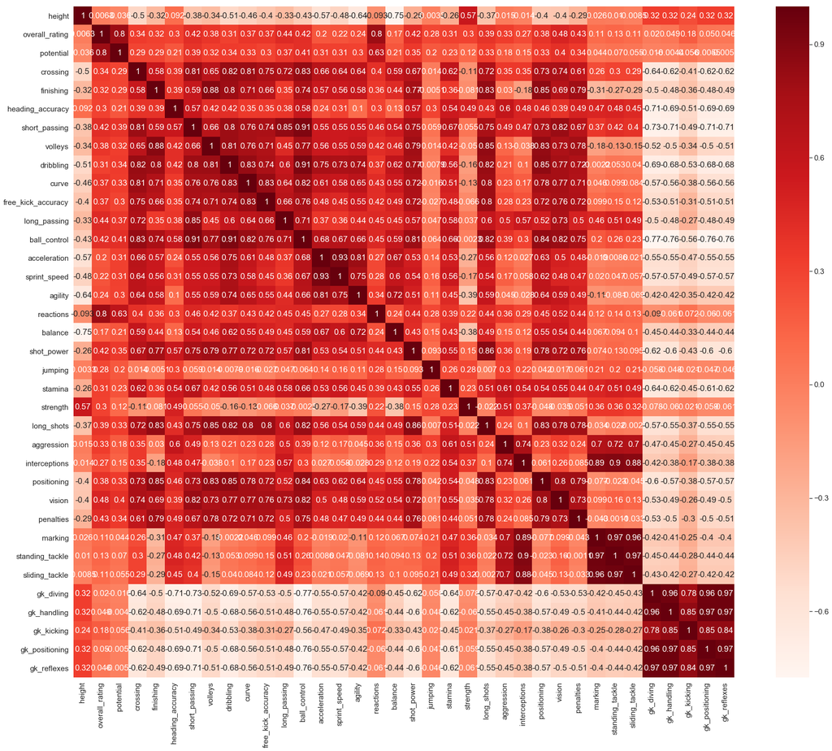

```python
# Plot heatmap
plt.figure(figsize=(30,25))
sns.heatmap(cor, annot=True, cmap=plt.cm.Reds);
```

```python
# Look at each feautre's correlation with overall_rating
cor_target = abs(cor["overall_rating"])
cor_target
```

```
height                0.006300
overall_rating        1.000000
potential             0.804617
crossing              0.341163
finishing             0.317317
heading_accuracy      0.299805
short_passing         0.422889
volleys               0.375118
dribbling             0.309086
curve                 0.372222
free_kick_accuracy    0.372496
long_passing          0.440110
ball_control          0.415304
acceleration          0.203590
sprint_speed          0.217754
agility               0.244829
reactions             0.799142
balance               0.166828
shot_power            0.419298
jumping               0.280155
stamina               0.307581
strength              0.299873
long_shots            0.387868
aggression            0.333203
interceptions         0.268084
positioning           0.384946
vision                0.482322
penalties             0.425534
marking               0.110907
standing_tackle       0.131782
sliding_tackle        0.106545
gk_diving             0.019516
gk_handling           0.048651
gk_kicking            0.178073
gk_positioning        0.050184
gk_reflexes           0.045869
Name: overall_rating, dtype: float64
```

```python
# Select highly correlated features to rating
features_to_rating = cor_target[cor_target>0.4]
features_to_rating.sort_values(ascending=False)
```

```
overall_rating    1.000000
potential         0.804617
reactions         0.799142
vision            0.482322
long_passing      0.440110
penalties         0.425534
short_passing     0.422889
shot_power        0.419298
ball_control      0.415304
Name: overall_rating, dtype: float64
```

```python
# Check the correlation of selected features with each other
features_to_rating_cor = player_clean_mean[["potential","reactions","vision","long_passing","penalties","short_passing","shot_power","ball_control"]].corr()
features_to_rating_cor
```

|  | potential | reactions | vision | long_passing | penalties | short_passing | shot_power | ball_control |
| --- | --- | --- | --- | --- | --- | --- | --- | --- |
| potential | 1.000000 | 0.628146 | 0.400215 | 0.368144 | 0.341469 | 0.388301 | 0.351801 | 0.405920 |
| reactions | 0.628146 | 1.000000 | 0.521903 | 0.446815 | 0.441569 | 0.464205 | 0.441081 | 0.454925 |
| vision | 0.400215 | 0.521903 | 1.000000 | 0.731559 | 0.727754 | 0.816361 | 0.716783 | 0.818466 |
| long_passing | 0.368144 | 0.446815 | 0.731559 | 1.000000 | 0.497619 | 0.846908 | 0.570679 | 0.713990 |
| penalties | 0.341469 | 0.441569 | 0.727754 | 0.497619 | 1.000000 | 0.671008 | 0.763612 | 0.748449 |
| short_passing | 0.388301 | 0.464205 | 0.816361 | 0.846908 | 0.671008 | 1.000000 | 0.746183 | 0.908023 |
| shot_power | 0.351801 | 0.441081 | 0.716783 | 0.570679 | 0.763612 | 0.746183 | 1.000000 | 0.805109 |
| ball_control | 0.405920 | 0.454925 | 0.818466 | 0.713990 | 0.748449 | 0.908023 | 0.805109 | 1.000000 |

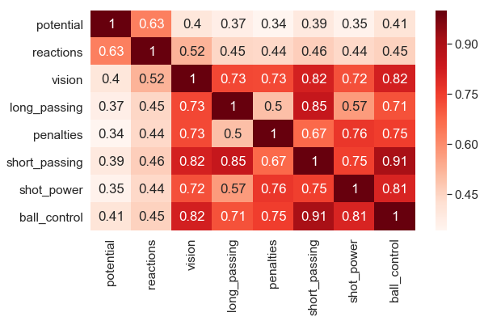

```python
# Create heatmap for selected features
plt.figure(figsize=(9,5))
sns.set(font_scale=1.4)
sns.heatmap(features_to_rating_cor, annot=True, cmap=plt.cm.Reds);
```

```python
# Find highly correlated pairs among selected features
features_to_rating_cor.unstack().sort_values(ascending=False).drop_duplicates()
```

```
ball_control   ball_control     1.000000
               short_passing    0.908023
long_passing   short_passing    0.846908
ball_control   vision           0.818466
vision         short_passing    0.816361
ball_control   shot_power       0.805109
penalties      shot_power       0.763612
ball_control   penalties        0.748449
short_passing  shot_power       0.746183
vision         long_passing     0.731559
               penalties        0.727754
               shot_power       0.716783
ball_control   long_passing     0.713990
penalties      short_passing    0.671008
reactions      potential        0.628146
shot_power     long_passing     0.570679
vision         reactions        0.521903
long_passing   penalties        0.497619
short_passing  reactions        0.464205
reactions      ball_control     0.454925
long_passing   reactions        0.446815
penalties      reactions        0.441569
shot_power     reactions        0.441081
potential      ball_control     0.405920
               vision           0.400215
               short_passing    0.388301
               long_passing     0.368144
shot_power     potential        0.351801
potential      penalties        0.341469
dtype: float64
```

```python
# Based on above list, select independent features (Here we set throghold of correlation = 0.75)
features_selected = player_comb_mean[["potential","reactions","vision","long_passing","penalties"]]
features_selected.corr()
```

[output not shown]

#### *Data visulization*

- To understand each selected features
- To better look at the relationship between overall_rating and each features

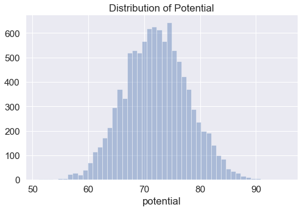

```python
# Look at the distribution of feature potential
plt.figure(figsize=(8,5))
sns.distplot(features_selected["potential"], kde=False, color="b")
plt.title("Distribution of Potential");
```

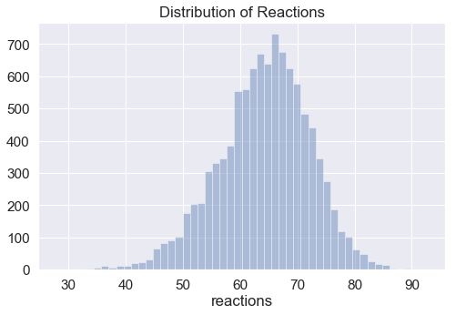

```python
# Look at the distribution of feature reactions
plt.figure(figsize=(8,5))
sns.distplot(features_selected["reactions"], kde=False, color="b")
plt.title("Distribution of Reactions");
```

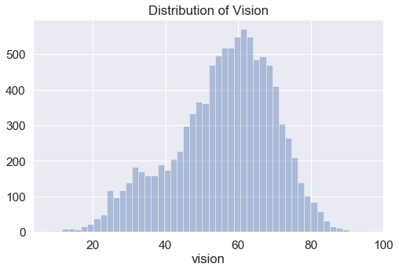

```python
# Look at the distribution of feature vision
plt.figure(figsize=(8,5))
sns.distplot(features_selected["vision"], kde=False, color="b")
plt.title("Distribution of Vision");
```

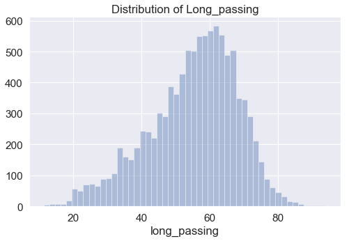

```python
# Look at the distribution of feature long_passing
plt.figure(figsize=(8,5))
sns.distplot(features_selected["long_passing"], kde=False, color="b")
plt.title("Distribution of Long_passing");
```

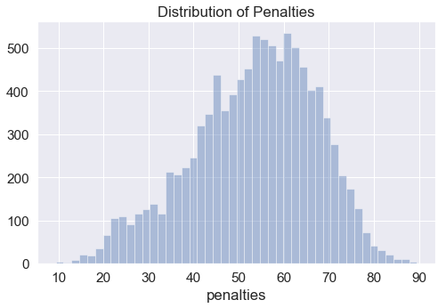

```python
# Look at the distribution of feature penalties
plt.figure(figsize=(8,5))
sns.distplot(features_selected["penalties"], kde=False, color="b")
plt.title("Distribution of Penalties");
```

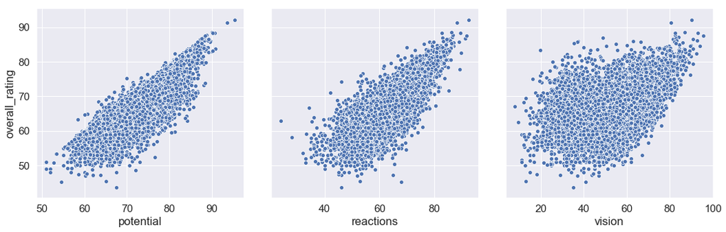

```python
#  Create a pairplot of overll_rating with potential, reactions, and vision
sns.pairplot(player_clean_mean, y_vars=['overall_rating'],
                  x_vars=['potential', 'reactions', 'vision'],height=5);
```

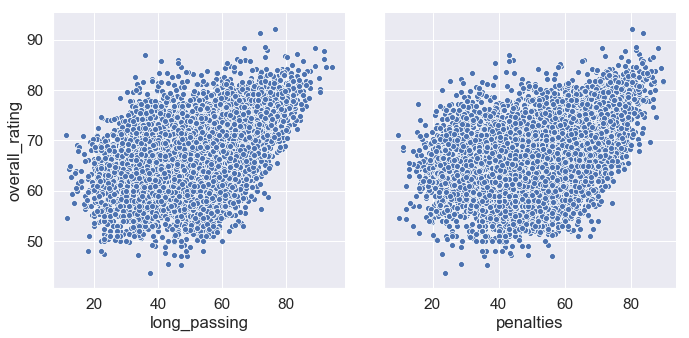

```python
#  Create a pairplot of overll_rating with long_passing, penalties, and short_passing
sns.pairplot(player_clean_mean, y_vars=['overall_rating'],
                  x_vars=['long_passing', "penalties"],height=5);
```

#### Summary:

- The features that are most correlated to overall_rating are potential, reactions, vision, long_passing and penalties.
- Except feature potential has normal distribution, other features show left-skewed somewhat.
- All selected features show positive relationship with overall_rating.

### Research Question 3: Which players had the most penalties?

```python
# List the top ten players having the most penalties
player_clean.groupby("player_name")['penalties'].sum().sort_values(ascending=False)[:10]
```

```
player_name
Alessio Cerci         4314.0
Mario Balotelli       4120.0
Claudio Marchisio     3984.0
Michael Bradley       3813.0
Zdravko Kuzmanovic    3799.0
Andrea Pirlo          3791.0
Antonio Di Natale     3767.0
Thierry Henry         3712.0
Adrien Silva          3682.0
Adel Taarabt          3650.0
Name: penalties, dtype: float64
```

```python
Alessio_Cerci = player_clean.query('player_name == "Alessio Cerci"').sort_values(by="date")
Alessio_Cerci.head()
```

|  | player_api_id | player_name | height | date | overall_rating | potential | crossing | finishing | heading_accuracy | short_passing | ... | vision | penalties | marking | standing_tackle | sliding_tackle | gk_diving | gk_handling | gk_kicking | gk_positioning | gk_reflexes |
| --- | --- | --- | --- | --- | --- | --- | --- | --- | --- | --- | --- | --- | --- | --- | --- | --- | --- | --- | --- | --- | --- |
| 6513 | 41269 | Alessio Cerci | 180.34 | 2007-02-22 | 70.0 | 71.0 | 47.0 | 68.0 | 69.0 | 71.0 | ... | 72.0 | 54.0 | 28.0 | 49.0 | 38.0 | 2.0 | 7.0 | 54.0 | 9.0 | 3.0 |
| 6512 | 41269 | Alessio Cerci | 180.34 | 2007-08-30 | 70.0 | 71.0 | 47.0 | 68.0 | 69.0 | 71.0 | ... | 72.0 | 54.0 | 28.0 | 49.0 | 38.0 | 2.0 | 20.0 | 54.0 | 20.0 | 20.0 |
| 6511 | 41269 | Alessio Cerci | 180.34 | 2008-08-30 | 77.0 | 86.0 | 81.0 | 74.0 | 53.0 | 76.0 | ... | 72.0 | 74.0 | 27.0 | 59.0 | 38.0 | 2.0 | 20.0 | 54.0 | 20.0 | 20.0 |
| 6510 | 41269 | Alessio Cerci | 180.34 | 2009-02-22 | 77.0 | 86.0 | 81.0 | 74.0 | 53.0 | 76.0 | ... | 72.0 | 74.0 | 27.0 | 59.0 | 38.0 | 2.0 | 20.0 | 54.0 | 20.0 | 20.0 |
| 6509 | 41269 | Alessio Cerci | 180.34 | 2009-08-30 | 75.0 | 86.0 | 78.0 | 71.0 | 53.0 | 72.0 | ... | 72.0 | 74.0 | 27.0 | 59.0 | 38.0 | 2.0 | 20.0 | 54.0 | 20.0 | 20.0 |

5 rows × 39 columns

```python
# Create a new column named as year
from datetime import datetime
Alessio_Cerci["year"]=Alessio_Cerci["date"].apply(lambda x: x.year)
Alessio_Cerci.head(1)
```

|  | player_api_id | player_name | height | date | overall_rating | potential | crossing | finishing | heading_accuracy | short_passing | ... | penalties | marking | standing_tackle | sliding_tackle | gk_diving | gk_handling | gk_kicking | gk_positioning | gk_reflexes | year |
| --- | --- | --- | --- | --- | --- | --- | --- | --- | --- | --- | --- | --- | --- | --- | --- | --- | --- | --- | --- | --- | --- |
| 6513 | 41269 | Alessio Cerci | 180.34 | 2007-02-22 | 70.0 | 71.0 | 47.0 | 68.0 | 69.0 | 71.0 | ... | 54.0 | 28.0 | 49.0 | 38.0 | 2.0 | 7.0 | 54.0 | 9.0 | 3.0 | 2007 |

1 rows × 40 columns

```python
# Calculate mean of penalties for each year
Alessio_Cerci_mean = Alessio_Cerci.groupby("year").mean()["penalties"]
Alessio_Cerci_mean
```

```
year
2007    54.000000
2008    74.000000
2009    74.000000
2010    72.000000
2011    70.000000
2012    70.000000
2013    78.000000
2014    81.583333
2015    78.818182
2016    77.333333
Name: penalties, dtype: float64
```

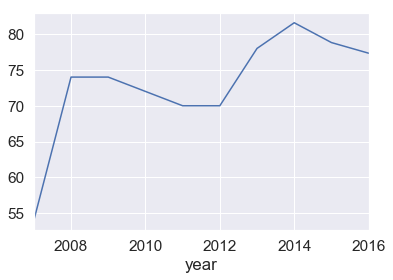

```python
# How Alessio Cerci's penalties change with time
Alessio_Cerci_mean.plot.line(x="date", y="penalties");
```

```python
# Obtain the highest penalties Alessio Cerci made at a time
Alessio_Cerci["penalties"].max()
```

```
82.0
```

```python
# In which date Allessio_Cerci made his highest penalties
Alessio_Cerci[Alessio_Cerci["penalties"]==Alessio_Cerci["penalties"].max()]["date"]
```

```
6488   2013-10-11
6487   2013-10-18
6486   2013-11-01
6485   2013-11-29
6484   2013-12-27
6483   2014-01-31
6482   2014-02-07
6481   2014-02-14
6480   2014-02-21
6479   2014-02-28
6478   2014-03-28
6477   2014-04-04
6476   2014-04-11
6475   2014-04-18
Name: date, dtype: datetime64[ns]
```

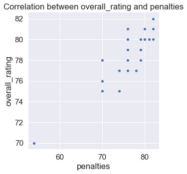

```python
# Use Alessio Cerci's data as an example to confirm the strong correlation between penalties and overall_rating
sns.pairplot(Alessio_Cerci, y_vars=['overall_rating'],
                  x_vars=['penalties'],height=5)
plt.title("Correlation between overall_rating and penalties");
```

#### Summary:

- Player Alessio Cerci made most penalties among the players recorded in the table.

## Limitation

- In this report, I only focus on Player and Player_Attributes tables. In the future, I can reacher further on how the players contributed to matches with their teams or leagues.
- The Player table has 212 repeated names. To avoid confusion, I changed the repeated names as their name. There is no additional efforts on checking the correction of each name except duplications.
- The Player_Attributes table contains thousand missing data. I had to drop the rows having any missing value inputs, which may have impact on evaluation of some idividual player performances.